# Map of New Mexico's Tribal lands and grocery stores

For this map I used data collected using ArcGIS, specifically data regarding New Mexico's grcoery stores and New Mexico's tribal lands.

```python
import os
os.chdir('C:\\Users\\jenat\\Documents\\new')

from mpl_toolkits.basemap import Basemap
import matplotlib as mpl
import numpy as np
from descartes import PolygonPatch
import geopandas as gp
import shapefile
from matplotlib.collections import LineCollection
import matplotlib.cm as cm
import matplotlib.pyplot as plt
import shapely
from matplotlib.collections import PatchCollection
import fiona
import shapely.geometry as geometry
import pylab as pl
from __future__ import print_function
from matplotlib.colors import rgb2hex
from matplotlib.patches import Polygon
```

```python
import os
os.chdir('C:\\Users\\jenat\\Documents\\new')

from mpl_toolkits.basemap import Basemap
import matplotlib as mpl
import numpy as np
from descartes import PolygonPatch
import geopandas as gp
import shapefile
from matplotlib.collections import LineCollection
import matplotlib.cm as cm
import matplotlib.pyplot as plt
from descartes import PolygonPatch
import shapely
earth = 'cornsilk'
from matplotlib.collections import PatchCollection
import fiona
import shapely.geometry as geometry
import pylab as pl
earth = 'cornsilk'
```

```python
glaciers = gp.GeoDataFrame.from_file('nm_gro - Copy.shp')

counties = gp.GeoDataFrame.from_file('nm_counties - Copy.shp')

tribal = gp.GeoDataFrame.from_file('nm_tl - Copy.shp')
```

Here is the head of the GeoPandas dataframe regarding New Mexico's grocery stores. I believe this data does NOT include gas stations.

```python
glaciers.head()
```

|  | BINOM_BEG | C | CM | COUNTY | C_rt | C_se | C_si | C_uc | EST_NAME | FID_ | ... | R_rm_c | R_rm_i | R_rm_j | R_ur | SOURCE | U | UID_JOIN_F | UID_JOIN_L | WD | geometry |
| --- | --- | --- | --- | --- | --- | --- | --- | --- | --- | --- | --- | --- | --- | --- | --- | --- | --- | --- | --- | --- | --- |
| 0 | 999999.0 | 0.0 | 0.0 | 31.0 | 0.0 | 0.0 | 0.0 | 0.0 | Albertsons - No902 | 0 | ... | None | None | None | None | D5 | 0.0 | 5538.0 | 5538.0 | 0.0 | POINT (-108.71737 35.529602) |
| 1 | 999999.0 | 0.0 | 0.0 | 27.0 | 0.0 | 0.0 | 0.0 | 0.0 | Wal Mart Super Center - No851 | 0 | ... | None | None | None | None | D1 | 0.0 | 788.0 | 788.0 | 0.0 | POINT (-105.547561 33.35897400000005) |
| 2 | 999999.0 | 0.0 | 0.0 | 9.0 | 0.0 | 0.0 | 0.0 | 0.0 | Albertsons - No916 | 0 | ... | None | None | None | None | D4 | 0.0 | 4077.0 | 4077.0 | 0.0 | POINT (-103.196493 34.41744100000002) |
| 3 | 999999.0 | 0.0 | 0.0 | 17.0 | 0.0 | 0.0 | 0.0 | 0.0 | Albertsons - No 914 | 0 | ... | None | None | None | None | D3 | 0.0 | 3580.0 | 3580.0 | 0.0 | POINT (-108.255132 32.78739199999997) |
| 4 | 999999.0 | 1.0 | 0.0 | 49.0 | 1.0 | 0.0 | 0.0 | 0.0 | Sunflower Farmers Markets | 0 | ... | None | None | None | None | D2 | 0.0 | 2023.0 | 2023.0 | 0.0 | POINT (-105.951133 35.69142899999996) |

5 rows × 69 columns

Here is the head of the tribal GeoPandas DataFrame.

```python
tribal.head()
```

|  | AIANNHCE00 | AIANNHID00 | AIANNHR00 | CLASSFP00 | COMPTYP00 | FID_ | FUNCSTAT00 | LSAD00 | MTFCC00 | NAME00 | NAMELSAD00 | geometry |
| --- | --- | --- | --- | --- | --- | --- | --- | --- | --- | --- | --- | --- |
| 0 | 2430 | 2430R | F | D8 | R | 0 | A | 86 | G2101 | Navajo Nation | Navajo Nation Reservation | (POLYGON ((-107.7396288784021 36.6471030979193... |
| 1 | 4470 | 4470R | F | D8 | R | 0 | A | 86 | G2101 | Ute Mountain | Ute Mountain Reservation | POLYGON ((-108.4628379999998 36.85005099999989... |
| 2 | 4785 | 4785R | F | D8 | R | 0 | A | 86 | G2101 | Zuni | Zuni Reservation | (POLYGON ((-109.0460690081911 34.8578950239504... |
| 3 | 0010 | 0010R | F | D8 | R | 0 | A | 84 | G2101 | Acoma | Acoma Pueblo | (POLYGON ((-107.5585460623441 35.0739959704343... |
| 4 | 2400 | 2400R | F | D8 | R | 0 | A | 84 | G2101 | Nambe | Nambe Pueblo | POLYGON ((-105.9289460000002 35.82681299999997... |

Now, here is the head of the counties GeoPandas dataframe

```python
counties.head()
```

|  | ALAND | AWATER | CBSAFP | CLASSFP | COUNTYFP | COUNTYNS | CSAFP | FID_ | FUNCSTAT | GEOID | INTPTLAT | INTPTLON | LSAD | METDIVFP | MTFCC | NAME | NAMELSAD | STATEFP | geometry |
| --- | --- | --- | --- | --- | --- | --- | --- | --- | --- | --- | --- | --- | --- | --- | --- | --- | --- | --- | --- |
| 0 | 7.679550e+09 | 431978.0 | 19700 | H1 | 029 | 00933057 | None | 0 | A | 35029 | +32.1844822 | -107.7466387 | 06 | None | G4020 | Luna | Luna County | 35 | POLYGON ((-108.2297870000003 32.20716300000004... |
| 1 | 8.901430e+09 | 23652092.0 | None | H1 | 023 | 00929106 | None | 0 | A | 35023 | +31.8996575 | -108.7457292 | 06 | None | G4020 | Hidalgo | Hidalgo County | 35 | POLYGON ((-109.0486389999999 31.92091300000003... |
| 2 | 1.026056e+10 | 15349508.0 | 43500 | H1 | 017 | 00915980 | None | 0 | A | 35017 | +32.7320870 | -108.3815043 | 06 | None | G4020 | Grant | Grant County | 35 | POLYGON ((-108.6594840000004 33.2093790000001,... |
| 3 | 3.006531e+09 | 16471227.0 | 10740 | H1 | 001 | 01702363 | None | 0 | A | 35001 | +35.0540019 | -106.6690645 | 06 | None | G4020 | Bernalillo | Bernalillo County | 35 | POLYGON ((-106.3731929999999 34.87033799999998... |
| 4 | 1.517950e+10 | 91459429.0 | 21580 | H1 | 039 | 01702368 | 492 | 0 | A | 35039 | +36.5096687 | -106.6939829 | 06 | None | G4020 | Rio Arriba | Rio Arriba County | 35 | POLYGON ((-106.9855130000004 37.00012999999998... |

Population density of all the tribes from the tribal land GeoDataframe

```python
popdensity = {
'Navajo Nation Reservation': 138.00,
'Ute Mountain Reservation': 337.35,
'Zuni Reservation':         312.68,
'Acoma Pueblo':             271.40,
'Nambe Pueblo':   209.23,
'Pojoaque Pueblo': 155.18,
'Tesuque Pueblo': 154.87,
'Mescalero Reservation': 114.43,
'Jicarilla Apache Nation Reservation': 107.05,
'San Felipe Pueblo': 105.80,
'San Ildefonso Pueblo': 86.27,
'Santo Domingo Pueblo': 83.85,
'Pueblo de Cochiti': 72.83,
'Laguna Pueblo': 69.03,
'Isleta Pueblo': 67.55,
'Sandia Pueblo': 65.46,
'Santa Clara Pueblo': 63.80,
'Zia Pueblo': 54.59,
'Jemez Pueblo': 53.29,
'Santa Ana Pueblo': 53.20,
'San Juan Pueblo': 51.45,
'Taos Pueblo': 39.61,
'Picuris Pueblo': 39.28,
'Navajo Nation Reservation': 138.00,
'Acoma Pueblo': 271.40,
'Zuni Reservation': 312.68,
'Laguna Pueblo': 69.03,
'Tesuque Pueblo': 154.87,
'Nambe Pueblo': 209.23,
'Zia Pueblo': 54.59,
'Taos Pueblo': 39.61,
'San Felipe/Santa Ana joint-use area': 38.13,
'San Felipe/Santo Domingo joint-use area': 34.20 }
```

Using the grocery dataframe, I will set my `x` and `y` values to the `latitude` and `longitude` values corresponding to the grocery stores locations. I will be using columns from this dataframe which are specificially longitude and latitude.

```python
y = glaciers.LAT.values
x = glaciers.LONG_.values
```

Composing the basemap of New Mexico:

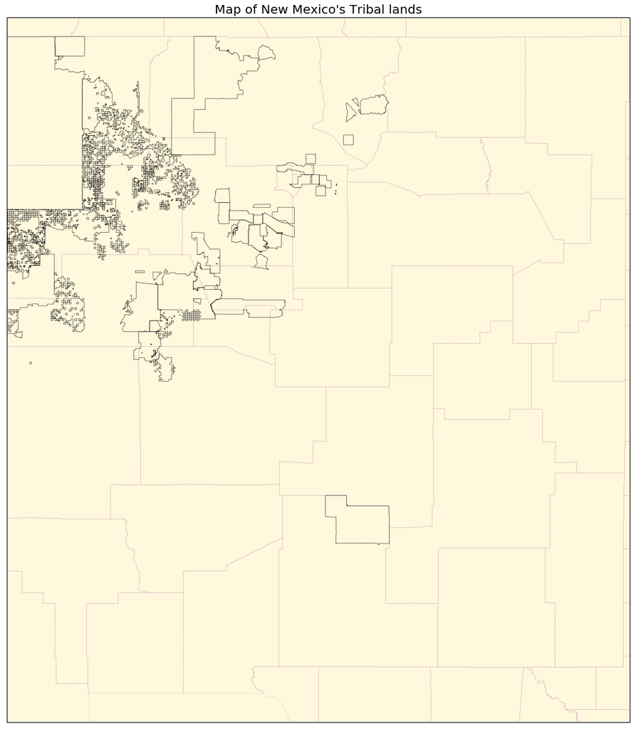

```python
fig, ax1 = plt.subplots(figsize=(18, 45))
map1 = Basemap(resolution='i',projection='merc',llcrnrlat=31.547, urcrnrlat=37.149, llcrnrlon=-109.0, urcrnrlon=-103.0)
map1.drawmapboundary(fill_color = 'lightskyblue')
map1.fillcontinents(color=earth)
map1.drawcounties(color='purple')
map1.readshapefile('nm_tl - Copy', name='states', drawbounds=True)
plt.title("Map of New Mexico's Tribal lands", fontsize = 20)
plt.show()
```

This is a map of the state of New Mexico, as well as a `shapefile` of the tribal lands which are outlined in `black`.

Now, I will colour in all the tribal land polygons.

```
['CLASSFP00', 'FID_', 'MTFCC00', 'LSAD00', 'NAME00', 'AIANNHR00', 'RINGNUM', 'AIANNHID00', 'FUNCSTAT00', 'NAMELSAD00', 'COMPTYP00', 'AIANNHCE00', 'SHAPENUM']
```

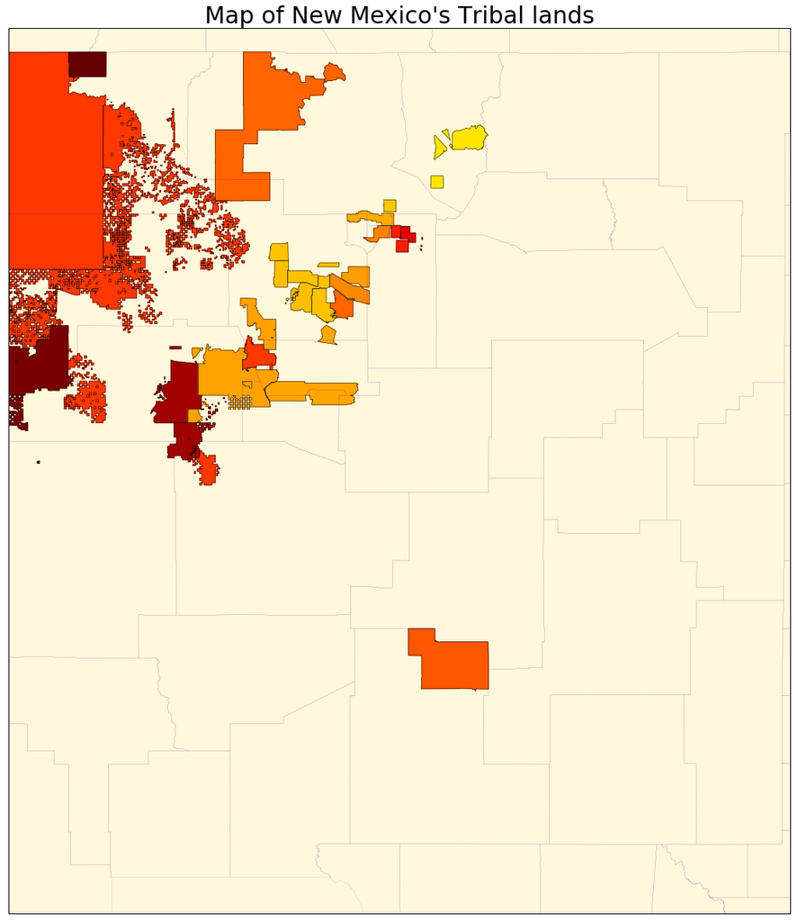

```python
fig, ax1 = plt.subplots(figsize=(18, 45))
map1 = Basemap(resolution='i',projection='merc',llcrnrlat=31.547, urcrnrlat=37.149, llcrnrlon=-109.0, urcrnrlon=-103.0)
map1.drawmapboundary(fill_color = 'lightskyblue')
map1.fillcontinents(color=earth)
map1.drawcounties(color='purple')
map1.readshapefile('nm_tl - Copy', name='states', drawbounds=True)


###

#colouring in the tribal lands

colors={}
statenames=[]
cmap = plt.cm.hot # use 'hot' colormap
vmin = 0; vmax = 450 # set range.
print(map1.states_info[0].keys())
for shapedict in map1.states_info:
    statename = shapedict['NAMELSAD00']
    if statename not in ['Cherokee','Sioux']:
        pop = popdensity[statename]
        # calling colormap with value between 0 and 1 returns
        # rgba value.  Invert color range (hot colors are high
        # population), take sqrt root to spread out colors more.
        colors[statename] = cmap(1.-np.sqrt((pop-vmin)/(vmax-vmin)))[:3]
    statenames.append(statename)
# cycle through state names, color each one.
ax = plt.gca() # get current axes instance
for nshape,seg in enumerate(map1.states):
    if statenames[nshape] not in ['Cherokee','Sioux']:
        color = rgb2hex(colors[statenames[nshape]])
        poly = Polygon(seg,facecolor=color,edgecolor=color)
        ax.add_patch(poly)
plt.title("Map of New Mexico's Tribal lands", fontsize = 30)
plt.show()
```

Next, I will add a scatter plot, which will indicate in blue the grocery stores located within New Mexico. It should be noted that the grocery store data does not include gas stations.

```
['CLASSFP00', 'FID_', 'MTFCC00', 'LSAD00', 'NAME00', 'AIANNHR00', 'RINGNUM', 'AIANNHID00', 'FUNCSTAT00', 'NAMELSAD00', 'COMPTYP00', 'AIANNHCE00', 'SHAPENUM']
```

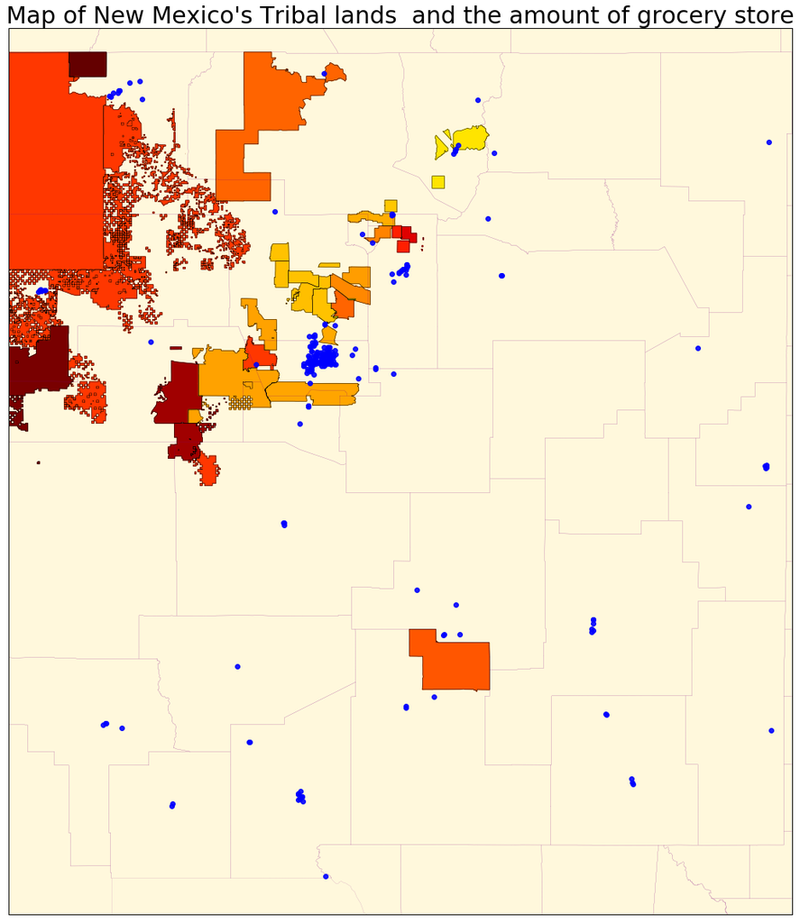

```python
fig, ax1 = plt.subplots(figsize=(18, 45))
map1 = Basemap(resolution='i',projection='merc',llcrnrlat=31.547, urcrnrlat=37.149, llcrnrlon=-109.0, urcrnrlon=-103.0)
map1.drawmapboundary(fill_color = 'lightskyblue')
map1.fillcontinents(color=earth)
map1.drawcounties(color='purple')
x1,y1 = map1(x, y)
map1.scatter(x1, y1, c = 'b',marker = "o", alpha = 0.9, zorder=10)
map1.readshapefile('nm_tl - Copy', name='states', drawbounds=True)


###

#colouring in the tribal lands

colors={}
statenames=[]
cmap = plt.cm.hot # use 'hot' colormap
vmin = 0; vmax = 450 # set range.
print(map1.states_info[0].keys())
for shapedict in map1.states_info:
    statename = shapedict['NAMELSAD00']
    if statename not in ['Cherokee','Sioux']:
        pop = popdensity[statename]
        # calling colormap with value between 0 and 1 returns
        # rgba value.  Invert color range (hot colors are high
        # population), take sqrt root to spread out colors more.
        colors[statename] = cmap(1.-np.sqrt((pop-vmin)/(vmax-vmin)))[:3]
    statenames.append(statename)
# cycle through state names, color each one.
ax = plt.gca() # get current axes instance
for nshape,seg in enumerate(map1.states):
    if statenames[nshape] not in ['Cherokee','Sioux']:
        color = rgb2hex(colors[statenames[nshape]])
        poly = Polygon(seg,facecolor=color,edgecolor=color)
        ax.add_patch(poly)
plt.title("Map of New Mexico's Tribal lands  and the amount of grocery store", fontsize = 30)
plt.show()
```

As we can see, the majority of grocery stores in New Mexico are not located within the tribal lands.